# 9 Analysis and synthesis

```r
library(grassland)
theme_set(ggthemes::theme_few())
```

Analyze individual species contributing to CTI-CPI change.

```r
dat_gainloss <- calc_species_gainloss(dat_community = dat_community, dat_niche = dat_niche)
# need to output to csv
```

```r
gg_species_change <- plot_species_gainloss(dat_niche = dat_niche, dat_gainloss = dat_gainloss)
```

```
#> [1] FALSE
#> [1] FALSE
```

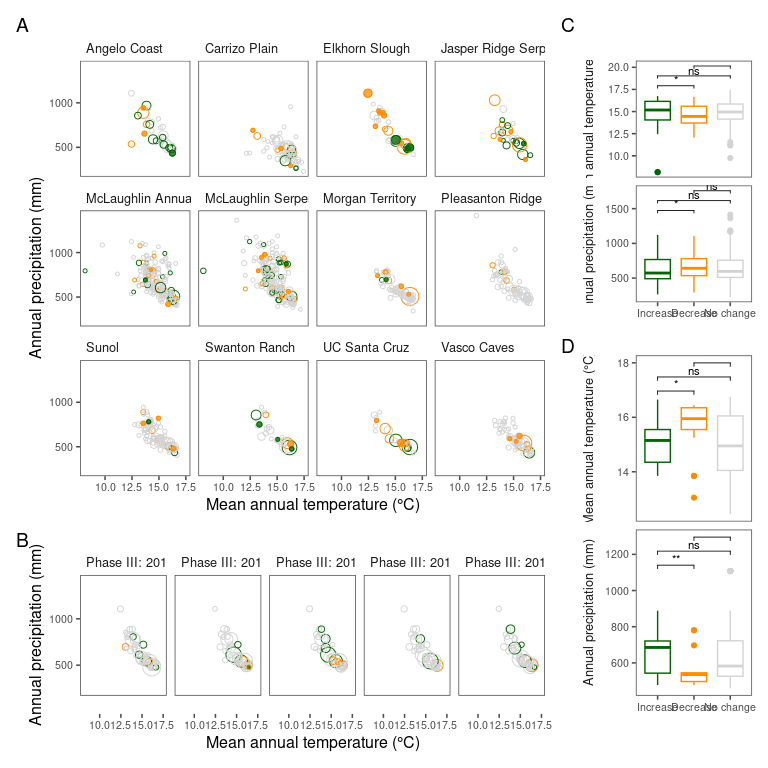

```r
gg_species_change$combined
```

```r
df_summ_species_change_obs <- summ_species_change(dat_gainloss, option = "obs")
df_summ_species_change_exp <- summ_species_change(dat_gainloss, option = "exp")
```

Across the observations, species gained in communities by significantly increasing abundance over time (e.g., *Bromus diandrus*) or recruitment (appeared only after the 5th yr, e.g., *Eschscholzia californica*); in contrast, species lost from communities by significantly decreasing abundance over time (e.g., *Festuca myuros*) or extirpation (disappeared in the last 5 yr, e.g., *Hypochaeris radicata*). In the experiment, species did not experience complete turnover, but some gained by being more abundant (e.g., *Torilis arvensis*), while some lost by being less abundant (e.g., *Brachypodium distachyon*) in warming compared to ambient plots.

Compare species rank abundance in observational communities over years and experimental communities across treatments. Test for difference in evenness in observational and experimental communities.

```r
dat_rank <- calc_rank_abundance(dat_community = dat_community)

dat_evenness <- calc_evenness(dat_community = dat_community)
df_evenness_summ <- test_evenness_change(dat_evenness = dat_evenness)
df_evenness_summ
```

```
#> $obs
#> # A tibble: 12 × 5
#> # Groups:   site [12]
#>    site            estimate std.error     p.value sig
#>    <chr>              <dbl>     <dbl>       <dbl> <chr>
#>  1 angelo           0.00658  0.00227  0.00497     "**"
#>  2 carrizo          0.00147  0.00226  0.517       " "
#>  3 elkhorn          0.00463  0.00190  0.0182      "*"
#>  4 jasper           0.00187  0.000582 0.00145     "**"
#>  5 mclann           0.00445  0.00107  0.0000379   "***"
#>  6 mclserp          0.00417  0.000906 0.00000524  "***"
#>  7 morganterritory  0.0421   0.00695  0.000000116 "***"
#>  8 pleasantonridge -0.00649  0.00326  0.0516      "."
#>  9 sunol           -0.00296  0.00542  0.586       " "
#> 10 swanton         -0.0196   0.00558  0.00114     "**"
```

[output cut: 23 more lines]

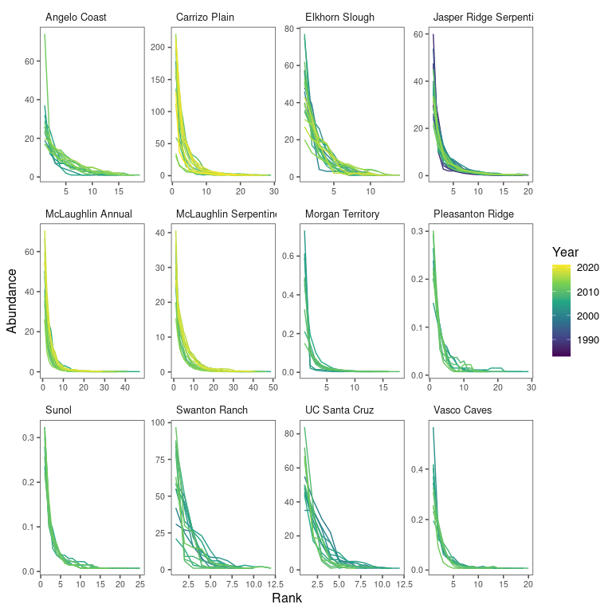

```r
gg_rank_abundance <- plot_rank_abundance(dat_rank = dat_rank, df_evenness_summ = df_evenness_summ)
gg_rank_abundance$obs
```

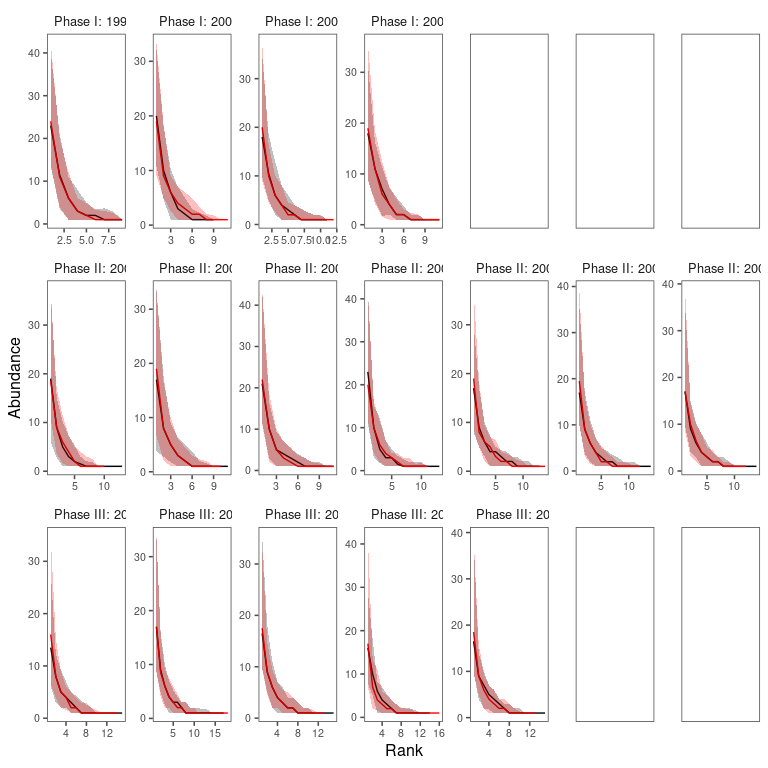

```r
gg_rank_abundance$exp
```

Due to the high correlation of species temperature and precipitation niches, CTI and CPI shifts at the community level appear highly coupled. Synthesize the coupled CTI-CPI shifts, both visually and numerically.

```r
dat_shift <- calc_community_shift(dat_index = dat_index)
```

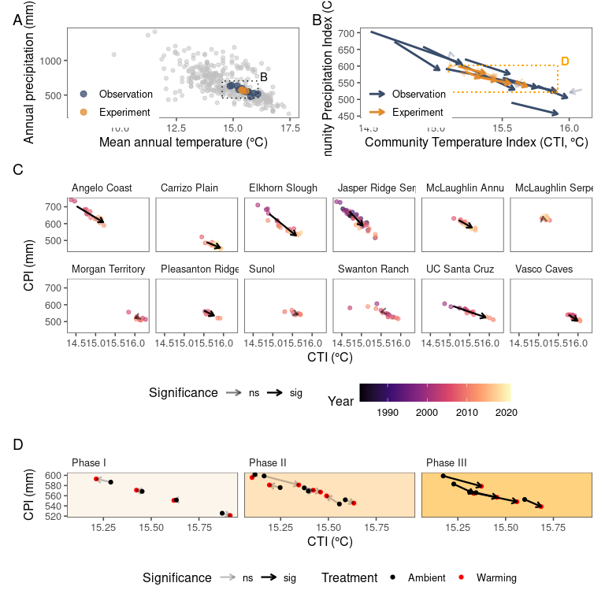

```r
gg_community_shift <- plot_community_shift(dat_shift, dat_niche)
gg_community_shift$combined
```

```r
df_summ_shift_coupling <- summ_shift_coupling(dat_shift)
df_summ_shift_coupling
```

```
#> # A tibble: 4 × 6
#>   ratio      group         median      min    max scale_factor
#>   <chr>      <fct>          <dbl>    <dbl>  <dbl>        <dbl>
#> 1 cpi_to_cti Observation -12.3    -156.     9.94           0.1
#> 2 cpi_to_cti Experiment   -9.28    -23.8   40.1            0.1
#> 3 cti_to_cpi Observation  -0.0666   -0.124  0.222         10
#> 4 cti_to_cpi Experiment   -0.0970   -0.128  0.223         10
```

A community thermophilization of 0.1 °C corresponded to a xerophilization of 12.3 mm from the observations and 9.28 mm from the experiment. Likewise, a community xerophilization of 10 mm corresponded to a thermophilization of 0.0666 °C from the observations and 0.097 °C from the experiment.

Output figures and R data files.

```r
save_figure(out = list(
  species_change = gg_species_change$combined,
  species_change_obs = gg_species_change$obs$circle_detail,
  species_change_exp = gg_species_change$exp$circle_detail,
  rank_abund_obs = gg_rank_abundance$obs,
  rank_abund_exp = gg_rank_abundance$exp,
  community_shift = gg_community_shift$combined
))

save_table(out = list(
  gainloss = dat_gainloss %>% tidy_table_gainloss()
))

save_rda(out = list(dat_gainloss, dat_shift))
```